# Bertrand paradox

# Introduction

The Bertrand paradox is a mathematical problem to show that probabilities may not be well defined if the mechanism or method that produces the random variable is not clearly defined.

This paradox was proposed by Joseph Bertrand in his work Calcul des probabilités (1889).

The paradox is as follows : Consider an equilateral triangle inscribed in a circle. Suppose a chord of the circle is chosen at random. What is the probability that the chord is longer than a side of the triangle (=$\sqrt{3}$)?

There are at least 3 methods to choose a chord **at random** and each gives a different result.

1. The “random endpoints” method Choose two random points on the circumference of the circle and take the chord between them. probability : *1/3*
2. The “random radius” method Choose a radius of the circle, choose a point on the radius and construct the chord through this point and perpendicular to the radius probability : *1/2*
3. The “random midpoint” method Choose a point anywhere within the circle and construct a chord with the chosen point as its midpoint. probability ; *1/4*

Why are those results different? I guessed this is because the probablistic distribution each follows is different. This is explaned below.

# Theory

1. The “random endpoints” method

This can be considered as follows : - Choose an angle $\theta$ - The angle follows an uniform distribution - Take the arc of the angle on a circle of radius 1. - Take the chord $c$ of the arc - $0\leq \theta \leq \pi$ ($\pi$, not $2\pi$, should be enough for the symmetry)

The geometry is below.

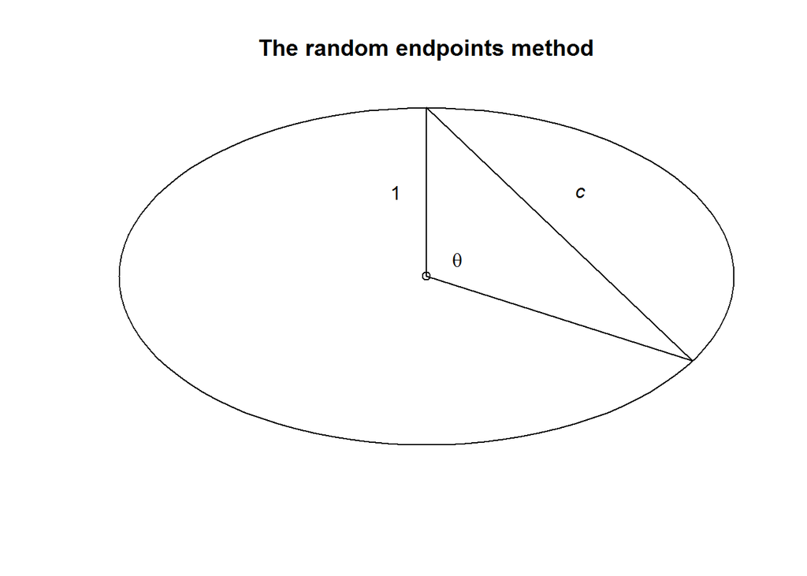

```r
plot(0,0, asp=1, xlab="", ylab="", xaxt="n", yaxt="n", bty="n", main="The random endpoints method")
angs <- seq(0, 2*pi, 2*pi/100)
polygon(cos(angs), sin(angs))
triangle <- c(c(0,0), c(0,1), c(cos(-pi/6), sin(-pi/6)), c(0,0))
triangle <- matrix(triangle, ncol=2, byrow=T)
polygon(triangle[,1], triangle[,2])
text(0.1, 0.1, expression(paste(theta)))
text(0.5, 0.5, expression(italic(c)))
text(-0.1, 0.5, expression(1))
```

$$c = 2sin(\theta/2)$$

Here’s one issue. $\theta$ follows a uniform distribution $P(\theta) = 1/\pi$ but what probablistic distribution does $c$ follow?

Let’s consider the following problem. What is $Q(x)$ below where x is a continuous random variable?

$$x \sim P(x) \\
f(x) \sim Q(x)$$

Since $x$ is with $P(x)$, the following is true.

$$P[a\leq X\leq b]=\int _{a}^{b}f(x)\,dx$$

Thus, the following is true.

$$P[A\leq f(X)\leq B] = P[a\leq f(X)\leq b] \\
(a=min(f^{-1}(A), f^{-1}(B)), b=max(f^{-1}(A), f^{-1}(B)))\\
=\int _{a}^{b}P(x)\,dx \\
=\int _{f^{-1}(A)}^{f^{-1}(B)}sign\,P(x)\,dx \\
(sign=
\begin{cases}
1\,\,(f^{-1}(B) \geq f^{-1}(A))\\
-1\,\,(f^{-1}(B) \lt f^{-1}(A))
\end{cases}
)\\
=\int _{A}^{B}sign\,P(f^{-1}(y))\,d{f^{-1}(y)} \\
=\int _{A}^{B}sign\,P(f^{-1}(y))\,\frac{d{f^{-1}(y)}}{dy} dy \\
\therefore Q(x) = sign\,P(f^{-1}(x))\,\frac{d{f^{-1}(x)}}{dx}$$

Thus, in this “random endpoints” method, where $P(x)=1/\pi$ and $f^{-1}(c) = 2 arcsin(c/2)$,$Q(c)$ is as follows.

$$Q(c) = sign\,P(f^{-1}(c))\,\frac{d{f^{-1}(c)}}{dc}\\
=\frac{1}{\pi \sqrt{1-(c/2)^2}}$$

Therefore, the probability that $c\gt\sqrt{3}$ is,

$$\int_{\sqrt{3}}^{2} \frac{1}{\pi \sqrt{1-(c/2)^2}} dc \\
=\int_{\frac{2\pi}{3}}^{\pi} \frac{1}{\pi} d\theta \\
= \frac{1}{\pi} (\pi - \frac{2\pi}{3}) \\
= \frac{1}{3}$$

This is consistent with the answer given.

2. The “random radius” method

This can be considered as follows : - Choose a radius of the circle - Choose a point on the radius (let the distance between the center of the circle and the point be $r$) - $0 \leq r \leq 1$ and $r \sim P(r) = 1$ - Make the chord through this point and perpendicular to the radius

The geometry is below.

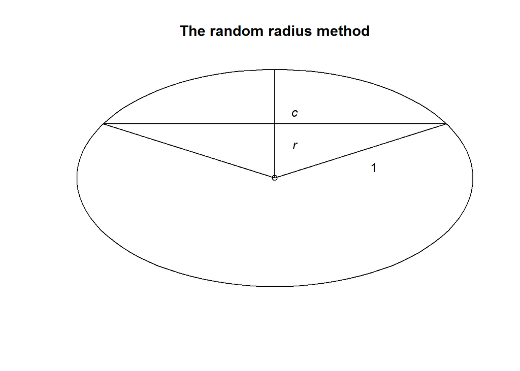

```r
plot(0,0, asp=1, xlab="", ylab="", xaxt="n", yaxt="n", bty="n", main="The random radius method")
angs <- seq(0, 2*pi, 2*pi/100)
polygon(cos(angs), sin(angs))
triangle <- c(c(0,0), c(cos(pi/6),sin(pi/6)), c(cos(5*pi/6), sin(5*pi/6)))
triangle <- matrix(triangle, ncol=2, byrow=T)
polygon(triangle[,1], triangle[,2])
lines(c(0,0), c(0,1))
text(0.1, 0.3, expression(italic(r)))
text(0.1, 0.6, expression(italic(c)))
text(0.5, 0.1, expression(1))
```

$$c = 2\sqrt{1-r^2} \\
\Leftrightarrow r=\sqrt{1-(c/2)^2}$$

We don’t have to consider “Choose a radius of the circle” when we build a model for the symmetry of a circle. Thus, in this “random radius” method, where $P(x)=1$ and $f^{-1}(c) = \sqrt{1-(c/2)^2}$,$Q(c)$ is as follows.

$$Q(c) = sign\,P(f^{-1}(c))\,\frac{d{f^{-1}(c)}}{dc}\\
=- \frac{d{f^{-1}(c)}}{dc}\\
=\frac{c}{4 \sqrt{1-(c/2)^2}}$$

Notice $sign = -1$ here. Therefore, the probability that $c\gt\sqrt{3}$ is,

$$\int_{2}^{\sqrt{3}} \frac{c}{4 \sqrt{1-(c/2)^2}} dc \\
= [\sqrt{1-(c/2)^2}]_{2}^{\sqrt{3}} \\
= \frac{1}{2}$$

This is consistent with the answer given.

3. The “random midpoint” method

Choose a point anywhere within the circle and construct a chord with the chosen point as its midpoint.

This can be considered as follows : - Choose a radius of the circle - Choose a point on the radius (let the distance between the center of the circle and the point be $r$) - $0 \leq r \leq 1$ and $r \sim P(r) = 2r$ - Make the chord through this point and perpendicular to the radius

The geometry is below.

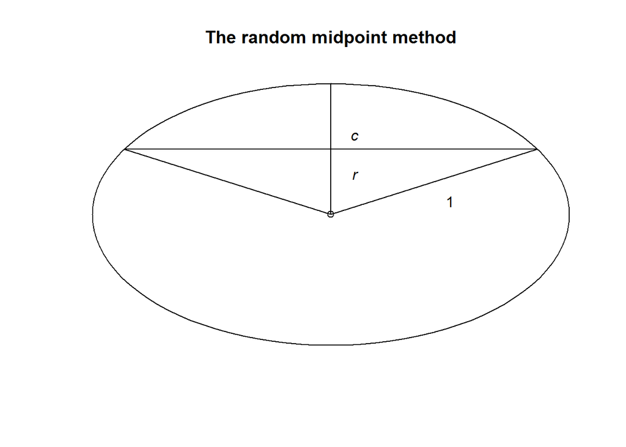

```r
plot(0,0, asp=1, xlab="", ylab="", xaxt="n", yaxt="n", bty="n", main="The random midpoint method")
angs <- seq(0, 2*pi, 2*pi/100)
polygon(cos(angs), sin(angs))
triangle <- c(c(0,0), c(cos(pi/6),sin(pi/6)), c(cos(5*pi/6), sin(5*pi/6)))
triangle <- matrix(triangle, ncol=2, byrow=T)
polygon(triangle[,1], triangle[,2])
lines(c(0,0), c(0,1))
text(0.1, 0.3, expression(italic(r)))
text(0.1, 0.6, expression(italic(c)))
text(0.5, 0.1, expression(1))
```

How can “Choose a point anywhere within the circle” be replaced with choosing a radius and a point on it?

The former can be alternatively expressed as “dividing a circle by $r$ and $\theta$ into infinite minute partitions and choosing one of them.” This is identical to choosing a radius of the circle (a “strip” of partitions) and a point (a specific partition) on it.

The geometry is as follows.

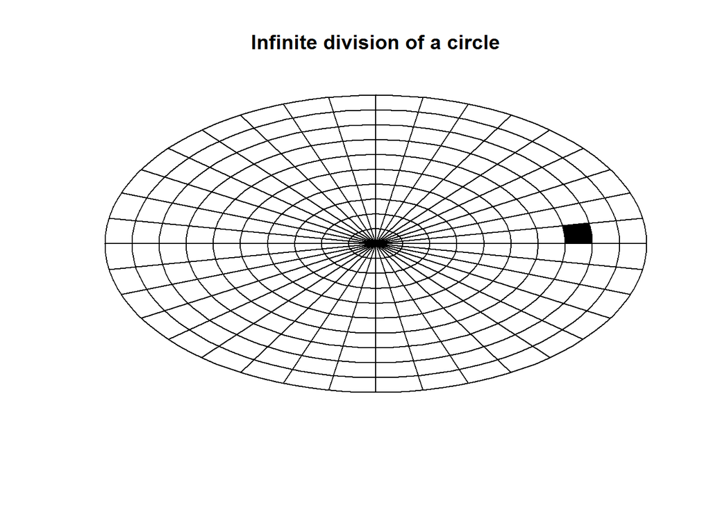

```r
plot(0,0, asp=1, xlab="", ylab="", xaxt="n", yaxt="n", bty="n", main="Infinite division of a circle")
angs <- seq(0, 2*pi, 2*pi/100)
for(i in 1:10) polygon(cos(angs)*i/10, sin(angs)*i/10)
angs <- seq(0, 2*pi, 2*pi/36)
for(i in 0:36) lines(c(0,cos(angs[i+1])), c(0,sin(angs[i+1])))
angs <- seq(0, 2*pi/36, 2*pi/360)
xs <- cos(angs)
ys <- sin(angs)
polygon(c(0.7*xs, 0.8*rev(xs)), c(0.7*ys, 0.8*rev(ys)), col="black")
```

The probability that each partition is picked should be based on its area. Let the radius and angle corresponding to the black square in the circle above be $r$ and $\theta$ then the area of the black square is $r\,dr\,d\theta$. So the probability that a partition is chosen is proportional to $r$. This is the background for $r \sim P(r) = 2r$. The integral $\int_0^1 C\,r\,dr=1$ gives $C=2$.

Let’s go back to the main part.

$$c = 2\sqrt{1-r^2} \\
\Leftrightarrow r=\sqrt{1-(c/2)^2}$$

We don’t have to consider “Choose a radius of the circle” when we build a model for the symmetry of a circle. Thus, in this “random midpoint” method, where $P(x)=2r$ and $f^{-1}(c) = \sqrt{1-(c/2)^2}$,$Q(c)$ is as follows.

$$Q(c) = sign\,P(f^{-1}(c))\,\frac{d{f^{-1}(c)}}{dc}\\
= -\,2\sqrt{1-(c/2)^2}\,\frac{d{\sqrt{1-(c/2)^2}}}{dc}\\
=\frac{c}{2}$$

Notice $sign = -1$ here. Therefore, the probability that $c\gt\sqrt{3}$ is,

$$\int_{\sqrt{3}}^{2} \frac{c}{2} dc \\
= [\frac{c^2}{4}]_{\sqrt{3}}^{2} \\
= \frac{1}{4}$$

This is consistent with the answer given.

# Experiment

Here we validate the model with computer simulation. The following function was used to create a histogram.

```r
library(ggplot2)
hist.chords <- function(df, theor.func){

  legend.title <- expression(paste("Is greater than ", sqrt(3)))

  g <- ggplot(df, aes(x = chords)) +
    ylim(0,4) +
    geom_histogram(aes(y=..density..)) +
    guides(fill=guide_legend(title=legend.title)) +
    stat_function(fun = theor.func,
                  lwd = 1,
                  col = 'red')
  plot(g)
}
```

1. The “random endpoints” method

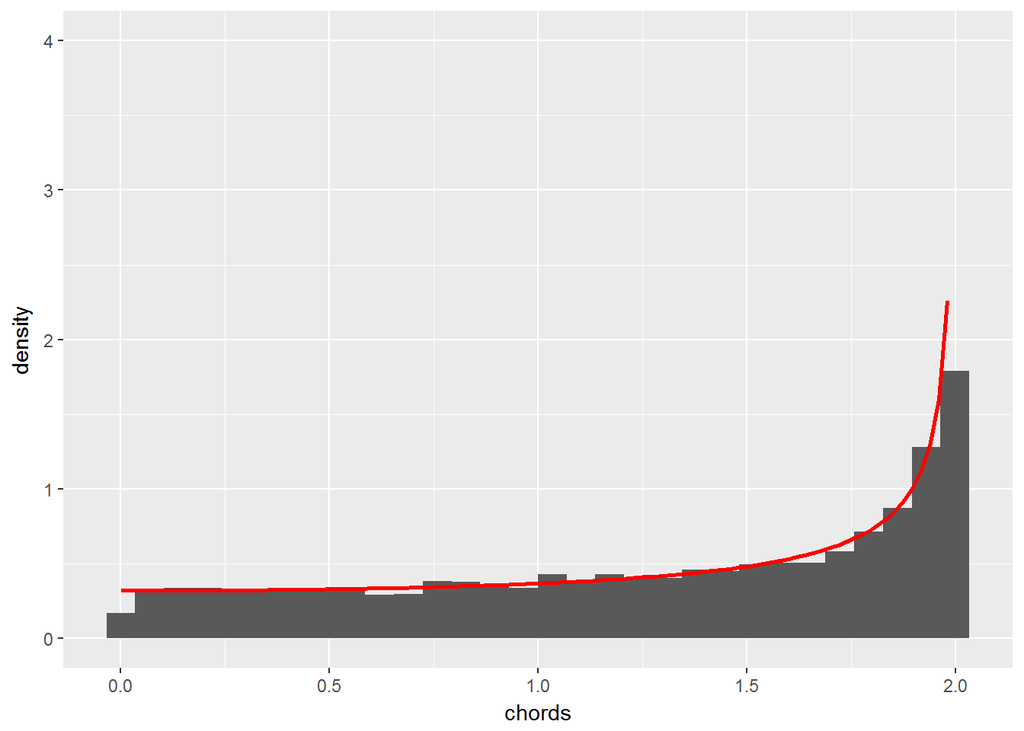

```r
set.seed(1)
n <- 10000
thetas <- runif(n, 0, pi)
chords <- 2*sin(thetas/2)
df <- data.frame(chords=chords, longer=chords>sqrt(3))
# theoretical curve for probablistic density
f <- function(x) 1/pi/sqrt(1-(x/2)^2)
# the probability that c > sqrt(3)
prob <- sum(df$chords>sqrt(3))/length(df$chords)
hist.chords(df, f)
```

The theoretical curve fits well to the histogram. The probability that $c\gt\sqrt{3}$ was 0.3367 = $\frac{1}{3}$.

2. The “random radius” method

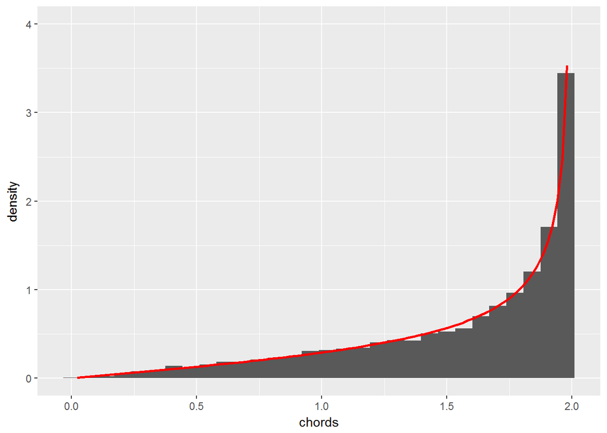

```r
set.seed(1)
n <- 10000
r <- runif(n, 0, 1)
chords <- 2*sqrt(1-r^2)
df <- data.frame(chords=chords, longer=chords>sqrt(3))
# theoretical curve for probablistic density
f <- function(x) x/4/sqrt(1-(x/2)^2)
# the probability that c > sqrt(3)
prob <- sum(df$chords>sqrt(3))/length(df$chords)
hist.chords(df, f)
```

The theoretical curve fits well to the histogram. The probability that $c\gt\sqrt{3}$ was 0.5047 = $\frac{1}{2}$.

3. The “random midpoint” method

The points in the circle were chosen as follows.

1. choose random points where $-1\leq x \leq 1$ and $-1\leq y \leq 1$
2. subset points within the circle of radius 1 and center at $(0,0)$

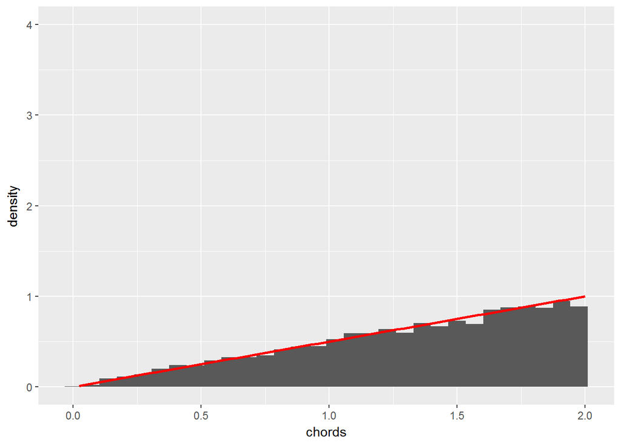

```r
set.seed(1)
n <- 10000
df <- data.frame(x=runif(n, -1, 1), y=runif(n, -1, 1))
df <- df[which(df$x^2 + df$y^2 < 1),]
r <- sqrt(df$x^2 + df$y^2)
chords <- 2*sqrt(1-r^2)
df <- data.frame(chords=chords, longer=chords>sqrt(3))
# theoretical curve for probablistic density
f <- function(x) x/2
# the probability that c > sqrt(3)
prob <- sum(df$chords>sqrt(3))/length(df$chords)
hist.chords(df, f)
```

The theoretical curve fits well to the histogram. The probability that $c\gt\sqrt{3}$ was 0.2494235 = $\frac{1}{4}$.

Another method to choose random points in the circle is as follows.

1. take $x$ where $0\leq x \leq 1$ and $x \sim P(x) = 1$
2. take $\sqrt{x} \sim P(x)=2x$ and call it $r$

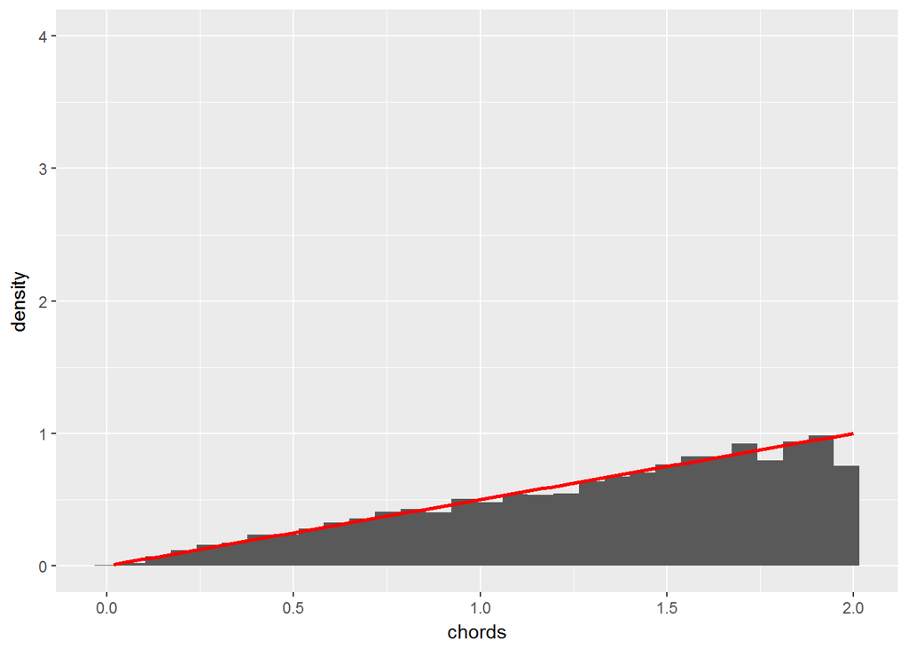

```r
set.seed(1)
n <- 10000
x <- runif(n, 0, 1)
r <- sqrt(x) # x~P(x)=2x
chords <- 2*sqrt(1-r^2)
df <- data.frame(chords=chords, longer=chords>sqrt(3))
# theoretical curve for probablistic density
f <- function(x) x/2
# the probability that c > sqrt(3)
prob <- sum(df$chords>sqrt(3))/length(df$chords)
hist.chords(df, f)
```

The theoretical curve fits well to the histogram. The probability that $c\gt\sqrt{3}$ was 0.2471 = $\frac{1}{4}$.

# Discussion

- The shapes of the models (red lines in the histograms) were quite different
- The probability of a chord being greater than $\sqrt{3}$ depends on the ratio of the area beyond $c=\sqrt{3}$
- The skewer the model curve is to the right, the higher the probability was

# Summary

- Mathematical models were obtained for each case of “random selections” in Bertrand paradox
- The models were validated with computer calculation whose results were pretty close to the models.
- “Randomness” should be carefully considered as different kinds of randomness may result in quite different conclusions as in this paradox.